# BioStrings and GenomicRanges

Paul Harrison

## Installing Bioconductor packages

```r
# This will install the packages used in this file.
source("http://www.bioconductor.org/biocLite.R")
biocLite(c(
    "GenomicRanges",
    "Biostrings",
    "BSgenome",
    "BSgenome.Scerevisiae.UCSC.sacCer3",
    "TxDb.Scerevisiae.UCSC.sacCer3.sgdGene",
    "seqLogo"))
```

### Load packages

```r
library(GenomicRanges)
library(Biostrings)
library(BSgenome)
```

## Finding documentation

Bioconductor packages usually have documentation in the form of “vignettes”. These are also available on the Bioconductor website: https://www.bioconductor.org/help/

```r
vignette()
vignette(package="Biostrings")
vignette("BiostringsQuickOverview")

browseVignettes()
```

## IRanges

Integer ranges, 1-based, from start to end inclusive.

This is R, where everything is a vector, so there is no singular IRange, only plural IRanges.

```r
myiranges <- IRanges(start=c(5,20,25), end=c(10,30,40))
```

Like all objects from Bioconductor, `myiranges` is an “S4” object. It has a class, which can be obtained with `class()`. This determines:

- The functions it can be used with (methods).
- What “slots” it has for storing data.

Data stored in slots is accessible with `@` (similar to `$` for lists), but code that uses accessor functions will be more generic and less liable to break in future.

```r
myiranges
```

```
## IRanges object with 3 ranges and 0 metadata columns:
##           start       end     width
##       <integer> <integer> <integer>
##   [1]         5        10         6
##   [2]        20        30        11
##   [3]        25        40        16
```

```r
class(myiranges)
```

```
## [1] "IRanges"
## attr(,"package")
## [1] "IRanges"
```

```r
methods(class="IRanges")
```

```
##   [1] !                   !=                  [
##   [4] [[                  [[<-                [<-
##   [7] %in%                <                   <=
##  [10] ==                  >                   >=
##  [13] $                   $<-                 aggregate
##  [16] anyNA               append              as.character
##  [19] as.complex          as.data.frame       as.env
##  [22] as.integer          as.list             as.logical
##  [25] as.matrix           as.numeric          as.raw
##  [28] as.vector           by                  c
##  [31] cbind               coerce              cor
##  [34] countOverlaps       cov                 coverage
##  [37] diff                disjoin             disjointBins
##  [40] distance            distanceToNearest   do.call
##  [43] drop                droplevels          duplicated
```

[output cut: 45 more lines]

```r
# ?"IRanges-class"

# Accessor functions
start(myiranges)
```

```
## [1]  5 20 25
```

```r
#(or myiranges@start, but start(myiranges) is preferable)
end(myiranges)
```

```
## [1] 10 30 40
```

```r
width(myiranges)
```

```
## [1]  6 11 16
```

```r
# IRanges supports many operations
resize(myiranges, 3, fix="start")
```

```
## IRanges object with 3 ranges and 0 metadata columns:
##           start       end     width
##       <integer> <integer> <integer>
##   [1]         5         7         3
##   [2]        20        22         3
##   [3]        25        27         3
```

```r
resize(myiranges, 3, fix="end")
```

```
## IRanges object with 3 ranges and 0 metadata columns:
##           start       end     width
##       <integer> <integer> <integer>
##   [1]         8        10         3
##   [2]        28        30         3
##   [3]        38        40         3
```

Ok, this gets confusing, let me illustrate.

```r
show_iranges <- function(obj) {
    for(i in seq_along(obj))
        cat(rep(" ", start(obj)[i]),
            rep("=", width(obj)[i]),
            "\n", sep="")
}

show_iranges( myiranges                              )
show_iranges( resize(myiranges, 3, fix="start")      )
show_iranges( resize(myiranges, 3, fix="end")        )
show_iranges( flank(myiranges, 2, start=TRUE)        )
show_iranges( flank(myiranges, 2, start=FALSE)       )
show_iranges( range(myiranges)                       )
show_iranges( reduce(myiranges)                      )
show_iranges( disjoin(myiranges)                     )
show_iranges( setdiff(range(myiranges), myiranges)   )
show_iranges( intersect(myiranges[2], myiranges[3])  )
show_iranges( union(myiranges[2], myiranges[3])      )
# ?"intra-range-methods"
# ?"inter-range-methods"
# ?"setops-methods"
# ?"findOverlaps-methods"
# ?"nearest-methods"
```

[output not shown]

**Note:** Loading tidyverse packages may clobber some of these generic functions. If necessary use `BiocGenerics::setdiff`, etc.

### Challenge

Without using the `promoters()` function, how would you get IRanges from -5 to +2 of the starts of `myiranges`?

## GRanges

To refer to a location in a genome we also need:

- sequence name (chromosome)
- strand, + or -

```r
mygranges <- GRanges(
    seqnames = c("chrII", "chrI", "chrI"),
    ranges = IRanges(start=c(5,20,25), end=c(10,30,40)),
    strand = c("+", "-", "+"))

mygranges
```

```
## GRanges object with 3 ranges and 0 metadata columns:
##       seqnames    ranges strand
##          <Rle> <IRanges>  <Rle>
##   [1]    chrII  [ 5, 10]      +
##   [2]     chrI  [20, 30]      -
##   [3]     chrI  [25, 40]      +
##   -------
##   seqinfo: 2 sequences from an unspecified genome; no seqlengths
```

```r
class(mygranges)
```

```
## [1] "GRanges"
## attr(,"package")
## [1] "GenomicRanges"
```

```r
methods(class="GRanges")
```

```
##   [1] !=                [                 [<-
##   [4] %in%              <                 <=
##   [7] ==                >                 >=
##  [10] $                 $<-               aggregate
##  [13] anyNA             append            as.character
##  [16] as.complex        as.data.frame     as.env
##  [19] as.factor         as.integer        as.list
##  [22] as.logical        as.matrix         as.numeric
##  [25] as.raw            blocks            browseGenome
##  [28] by                c                 chrom
##  [31] chrom<-           coerce            coerce<-
##  [34] countOverlaps     coverage          disjoin
##  [37] disjointBins      distance          distanceToNearest
##  [40] duplicated        elementMetadata   elementMetadata<-
##  [43] end               end<-             eval
```

[output cut: 34 more lines]

```r
# ?"GRanges-class"

seqnames(mygranges)
```

```
## factor-Rle of length 3 with 2 runs
##   Lengths:     1     2
##   Values : chrII  chrI
## Levels(2): chrII chrI
```

```r
strand(mygranges)
```

```
## factor-Rle of length 3 with 3 runs
##   Lengths: 1 1 1
##   Values : + - +
## Levels(3): + - *
```

```r
ranges(mygranges)
```

```
## IRanges object with 3 ranges and 0 metadata columns:
##           start       end     width
##       <integer> <integer> <integer>
##   [1]         5        10         6
##   [2]        20        30        11
##   [3]        25        40        16
```

```r
start(mygranges)
```

```
## [1]  5 20 25
```

```r
end(mygranges)
```

```
## [1] 10 30 40
```

```r
as.data.frame(mygranges)
```

```
##   seqnames start end width strand
## 1    chrII     5  10     6      +
## 2     chrI    20  30    11      -
## 3     chrI    25  40    16      +
```

```r
# GRanges are like vectors:
mygranges[2]
```

```
## GRanges object with 1 range and 0 metadata columns:
##       seqnames    ranges strand
##          <Rle> <IRanges>  <Rle>
##   [1]     chrI  [20, 30]      -
##   -------
##   seqinfo: 2 sequences from an unspecified genome; no seqlengths
```

```r
c(mygranges, mygranges)
```

```
## GRanges object with 6 ranges and 0 metadata columns:
##       seqnames    ranges strand
##          <Rle> <IRanges>  <Rle>
##   [1]    chrII  [ 5, 10]      +
##   [2]     chrI  [20, 30]      -
##   [3]     chrI  [25, 40]      +
##   [4]    chrII  [ 5, 10]      +
##   [5]     chrI  [20, 30]      -
##   [6]     chrI  [25, 40]      +
##   -------
##   seqinfo: 2 sequences from an unspecified genome; no seqlengths
```

```r
# Like other vectors, elements may be named
names(mygranges) <- c("foo", "bar", "baz")
mygranges
```

```
## GRanges object with 3 ranges and 0 metadata columns:
##       seqnames    ranges strand
##          <Rle> <IRanges>  <Rle>
##   foo    chrII  [ 5, 10]      +
##   bar     chrI  [20, 30]      -
##   baz     chrI  [25, 40]      +
##   -------
##   seqinfo: 2 sequences from an unspecified genome; no seqlengths
```

```r
# GRanges can have metadata columns, so they are also a little like data frames:
mygranges$wobble <- c(10, 20, 30)
mygranges
```

```
## GRanges object with 3 ranges and 1 metadata column:
##       seqnames    ranges strand |    wobble
##          <Rle> <IRanges>  <Rle> | <numeric>
##   foo    chrII  [ 5, 10]      + |        10
##   bar     chrI  [20, 30]      - |        20
##   baz     chrI  [25, 40]      + |        30
##   -------
##   seqinfo: 2 sequences from an unspecified genome; no seqlengths
```

```r
mcols(mygranges)
```

```
## DataFrame with 3 rows and 1 column
##      wobble
##   <numeric>
## 1        10
## 2        20
## 3        30
```

```r
mygranges$wobble
```

```
## [1] 10 20 30
```

```r
# A handy way to create a GRanges
as("chrI:3-5:+", "GRanges")
```

```
## GRanges object with 1 range and 0 metadata columns:
##       seqnames    ranges strand
##          <Rle> <IRanges>  <Rle>
##   [1]     chrI    [3, 5]      +
##   -------
##   seqinfo: 1 sequence from an unspecified genome; no seqlengths
```

```r
# All the operations we saw for IRanges are available for GRanges.
# However most GRanges operations will take strand into account.
#
# Warning: shift() is a notable exception to this.

resize(mygranges, 3, fix="start")
```

```
## GRanges object with 3 ranges and 1 metadata column:
##       seqnames    ranges strand |    wobble
##          <Rle> <IRanges>  <Rle> | <numeric>
##   foo    chrII  [ 5,  7]      + |        10
##   bar     chrI  [28, 30]      - |        20
##   baz     chrI  [25, 27]      + |        30
##   -------
##   seqinfo: 2 sequences from an unspecified genome; no seqlengths
```

```r
resize(mygranges, 3, fix="end")
```

```
## GRanges object with 3 ranges and 1 metadata column:
##       seqnames    ranges strand |    wobble
##          <Rle> <IRanges>  <Rle> | <numeric>
##   foo    chrII  [ 8, 10]      + |        10
##   bar     chrI  [20, 22]      - |        20
##   baz     chrI  [38, 40]      + |        30
##   -------
##   seqinfo: 2 sequences from an unspecified genome; no seqlengths
```

## DNAString and DNAStringSet

### DNAString

A DNAString is like a character string of bases “A”, “C”, “G”, “T”, or possibly IUPAC ambiguity codes such as “N” for any base.

```r
myseq <- DNAString("gcgctgctggatgcgaccgcgcatgcgagcgcgacctatccggaa")

myseq
```

```
##   45-letter "DNAString" instance
## seq: GCGCTGCTGGATGCGACCGCGCATGCGAGCGCGACCTATCCGGAA
```

```r
class(myseq)
```

```
## [1] "DNAString"
## attr(,"package")
## [1] "Biostrings"
```

```r
methods(class="DNAString")
```

```
##   [1] !=                              [
##   [3] [<-                             %in%
##   [5] <                               <=
##   [7] ==                              >
##   [9] >=                              aggregate
##  [11] alphabetFrequency               anyNA
##  [13] append                          as.character
##  [15] as.complex                      as.data.frame
##  [17] as.env                          as.integer
##  [19] as.list                         as.logical
##  [21] as.matrix                       as.numeric
##  [23] as.raw                          as.vector
##  [25] by                              c
##  [27] chartr                          codons
##  [29] coerce                          compact
```

[output cut: 61 more lines]

```r
# ?"DNAString-class"

reverseComplement(myseq)
```

```
##   45-letter "DNAString" instance
## seq: TTCCGGATAGGTCGCGCTCGCATGCGCGGTCGCATCCAGCAGCGC
```

```r
translate(myseq)
```

```
##   15-letter "AAString" instance
## seq: ALLDATAHASATYPE
```

```r
subseq(myseq, 3,5)
```

```
##   3-letter "DNAString" instance
## seq: GCT
```

```r
alphabetFrequency(myseq)
```

```
##  A  C  G  T  M  R  W  S  Y  K  V  H  D  B  N  -  +  .
##  8 15 16  6  0  0  0  0  0  0  0  0  0  0  0  0  0  0
```

```r
letterFrequency(myseq, c("AT", "GC"))
```

```
## A|T G|C
##  14  31
```

```r
# DNAString objects behave like vectors.
myseq[3:5]
```

```
##   3-letter "DNAString" instance
## seq: GCT
```

```r
c(myseq, myseq)
```

```
##   90-letter "DNAString" instance
## seq: GCGCTGCTGGATGCGACCGCGCATGCGAGCGCGA...GCGACCGCGCATGCGAGCGCGACCTATCCGGAA
```

```r
# as() converts between types.
as(myseq, "character")
```

```
## [1] "GCGCTGCTGGATGCGACCGCGCATGCGAGCGCGACCTATCCGGAA"
```

```r
as("ACGT", "DNAString")
```

```
##   4-letter "DNAString" instance
## seq: ACGT
```

#### Finding or counting patterns

```r
matchPattern("GCG", myseq)
```

```
##   Views on a 45-letter DNAString subject
## subject: GCGCTGCTGGATGCGACCGCGCATGCGAGCGCGACCTATCCGGAA
## views:
##     start end width
## [1]     1   3     3 [GCG]
## [2]    13  15     3 [GCG]
## [3]    19  21     3 [GCG]
## [4]    25  27     3 [GCG]
## [5]    29  31     3 [GCG]
## [6]    31  33     3 [GCG]
```

```r
countPattern("GCG", myseq)
```

```
## [1] 6
```

These functions have arguments to allow for some number of substitutions, or even substitutions, insertions, and deletions.

Use `pairwiseAlignment()` for more flexible local or global alignment.

Use `matchPWM()` for a motif represented as a Position Weight Matrix.

### DNAStringSet

We often want to work with a collection of DNA sequences.

```r
myset <- DNAStringSet(list(chrI=myseq, chrII=DNAString("ACGTACGTAA")))

myset
```

```
##   A DNAStringSet instance of length 2
##     width seq                                          names
## [1]    45 GCGCTGCTGGATGCGACCGCG...CGAGCGCGACCTATCCGGAA chrI
## [2]    10 ACGTACGTAA                                   chrII
```

```r
class(myset)
```

```
## [1] "DNAStringSet"
## attr(,"package")
## [1] "Biostrings"
```

```r
# ?"DNAStringSet-class"

elementNROWS(myset)
```

```
## [1] 45 10
```

```r
seqinfo(myset)
```

```
## Seqinfo object with 2 sequences from an unspecified genome:
##   seqnames seqlengths isCircular genome
##   chrI             45         NA   <NA>
##   chrII            10         NA   <NA>
```

```r
# Since a DNAString is like a vector, a DNAStringSet is has to be like a list.
myset$chrII
```

```
##   10-letter "DNAString" instance
## seq: ACGTACGTAA
```

```r
# or myset[["chrII"]]
# or myset[[2]]

# Getting sequences with GRanges
getSeq(myset, mygranges)
```

```
##   A DNAStringSet instance of length 3
##     width seq
## [1]     6 ACGTAA
## [2]    11 GCTCGCATGCG
## [3]    16 GCGAGCGCGACCTATC
```

```r
getSeq(myset, as("chrI:1-3:+", "GRanges"))
```

```
##   A DNAStringSet instance of length 1
##     width seq
## [1]     3 GCG
```

```r
getSeq(myset, as("chrI:1-3:-", "GRanges"))
```

```
##   A DNAStringSet instance of length 1
##     width seq
## [1]     3 CGC
```

```r
# Performs reverse complement if strand is "-".
```

GRanges can also have seqinfo, allowing various forms of error checking.

### Challenge

Reverse complement the following DNA sequence and then translate to an amino acid sequence:

```
TTCCATTTCCAT
```

## BSgenome and TxDb packages

Genomes and genes for many model organisms are available as Bioconductor packages.

- BSgenome. … - Genomes as DNAStringSet-like objects
- TxDB. … - Genes, transcripts, exons, CDS as GRanges
- org. … - Translation of gene names, assignment to GO categories, etc

Further data may be available using AnnotationHub.

We will be using packages for yeast in this part of the workshop.

```r
library(BSgenome.Scerevisiae.UCSC.sacCer3)
# A yeast genome object has been loaded.
# Actual sequence data is only loaded from disk as needed.
genome <- Scerevisiae

class(genome)
```

```
## [1] "BSgenome"
## attr(,"package")
## [1] "BSgenome"
```

```r
# ?"BSgenome-class"

seqinfo(genome)
```

```
## Seqinfo object with 17 sequences (1 circular) from sacCer3 genome:
##   seqnames seqlengths isCircular  genome
##   chrI         230218      FALSE sacCer3
##   chrII        813184      FALSE sacCer3
##   chrIII       316620      FALSE sacCer3
##   chrIV       1531933      FALSE sacCer3
##   chrV         576874      FALSE sacCer3
##   ...             ...        ...     ...
##   chrXIII      924431      FALSE sacCer3
##   chrXIV       784333      FALSE sacCer3
##   chrXV       1091291      FALSE sacCer3
##   chrXVI       948066      FALSE sacCer3
##   chrM          85779       TRUE sacCer3
```

```r
genome$chrM
```

```
##   85779-letter "DNAString" instance
## seq: TTCATAATTAATTTTTTATATATATATTATATTA...AGAAATATGCTTAATTATAATATAATATCCATA
```

```r
library(TxDb.Scerevisiae.UCSC.sacCer3.sgdGene)
# An object referring to a yeast transcriptome database has been loaded.
# Actual data is only loaded from disk as needed.
txdb <- TxDb.Scerevisiae.UCSC.sacCer3.sgdGene

class(txdb)
```

```
## [1] "TxDb"
## attr(,"package")
## [1] "GenomicFeatures"
```

```r
# ?"TxDb-class"
```

Genes have transcripts. Transcripts have exons, and CDSs if they are protein coding.

The GRange for a transcript spans all of its exons. The GRange for a gene spans all the exons of all of its transcripts.

For example:

```
=============================================== gene

========================  transcript1 of gene
=======   ====  ========  exons of transcript1
   ====   ====  ===       CDSs of transcript1

        ======================================= transcript2 of gene
        ======              ======   ========== exons of transcript2
          ====              ======   ===        CDSs of transcript2
```

```r
genes(txdb)
```

```
## GRanges object with 6534 ranges and 1 metadata column:
##             seqnames           ranges strand |     gene_id
##                <Rle>        <IRanges>  <Rle> | <character>
##       Q0010     chrM   [ 3952,  4415]      + |       Q0010
##       Q0032     chrM   [11667, 11957]      + |       Q0032
##       Q0055     chrM   [13818, 26701]      + |       Q0055
##       Q0075     chrM   [24156, 25255]      + |       Q0075
##       Q0080     chrM   [27666, 27812]      + |       Q0080
##         ...      ...              ...    ... .         ...
##     YPR200C   chrXVI [939279, 939671]      - |     YPR200C
##     YPR201W   chrXVI [939922, 941136]      + |     YPR201W
##     YPR202W   chrXVI [943032, 944188]      + |     YPR202W
##   YPR204C-A   chrXVI [946856, 947338]      - |   YPR204C-A
##     YPR204W   chrXVI [944603, 947701]      + |     YPR204W
##   -------
##   seqinfo: 17 sequences (1 circular) from sacCer3 genome
```

```r
transcriptsBy(txdb, "gene")
```

```
## GRangesList object of length 6534:
## $Q0010
## GRanges object with 2 ranges and 2 metadata columns:
##       seqnames       ranges strand |     tx_id     tx_name
##          <Rle>    <IRanges>  <Rle> | <integer> <character>
##   [1]     chrM [3952, 4338]      + |      6665       Q0010
##   [2]     chrM [4254, 4415]      + |      6666       Q0017
##
## $Q0032
## GRanges object with 1 range and 2 metadata columns:
##       seqnames         ranges strand | tx_id tx_name
##   [1]     chrM [11667, 11957]      + |  6667   Q0032
##
## $Q0055
## GRanges object with 6 ranges and 2 metadata columns:
##       seqnames         ranges strand | tx_id tx_name
##   [1]     chrM [13818, 16322]      + |  6668   Q0050
##   [2]     chrM [13818, 18830]      + |  6669   Q0055
##   [3]     chrM [13818, 19996]      + |  6670   Q0060
##   [4]     chrM [13818, 21935]      + |  6671   Q0065
##   [5]     chrM [13818, 23167]      + |  6672   Q0070
##   [6]     chrM [13818, 26701]      + |  6673   Q0045
##
## ...
## <6531 more elements>
## -------
## seqinfo: 17 sequences (1 circular) from sacCer3 genome
```

```r
exonsBy(txdb, "tx", use.names=TRUE)
```

```
## GRangesList object of length 6692:
## $YAL069W
## GRanges object with 1 range and 3 metadata columns:
##       seqnames     ranges strand |   exon_id   exon_name exon_rank
##          <Rle>  <IRanges>  <Rle> | <integer> <character> <integer>
##   [1]     chrI [335, 649]      + |         1        <NA>         1
##
## $YAL068W-A
## GRanges object with 1 range and 3 metadata columns:
##       seqnames     ranges strand | exon_id exon_name exon_rank
##   [1]     chrI [538, 792]      + |       2      <NA>         1
##
## $YAL067W-A
## GRanges object with 1 range and 3 metadata columns:
##       seqnames       ranges strand | exon_id exon_name exon_rank
##   [1]     chrI [2480, 2707]      + |       3      <NA>         1
##
## ...
## <6689 more elements>
## -------
## seqinfo: 17 sequences (1 circular) from sacCer3 genome
```

```r
cdsBy(txdb, "tx", use.names=TRUE)
```

```
## GRangesList object of length 6692:
## $YAL069W
## GRanges object with 1 range and 3 metadata columns:
##       seqnames     ranges strand |    cds_id    cds_name exon_rank
##          <Rle>  <IRanges>  <Rle> | <integer> <character> <integer>
##   [1]     chrI [335, 649]      + |         1        <NA>         1
##
## $YAL068W-A
## GRanges object with 1 range and 3 metadata columns:
##       seqnames     ranges strand | cds_id cds_name exon_rank
##   [1]     chrI [538, 792]      + |      2     <NA>         1
##
## $YAL067W-A
## GRanges object with 1 range and 3 metadata columns:
##       seqnames       ranges strand | cds_id cds_name exon_rank
##   [1]     chrI [2480, 2707]      + |      3     <NA>         1
##
## ...
## <6689 more elements>
## -------
## seqinfo: 17 sequences (1 circular) from sacCer3 genome
```

### Example: extracting start codons

To illustrate the use of a TxDb, let us try to extract the start codons of yeast. Our first step is to obtain the locations of the coding sequences.

```r
cds_list <- cdsBy(txdb, "tx", use.names=TRUE)

cds_list
```

```
## GRangesList object of length 6692:
## $YAL069W
## GRanges object with 1 range and 3 metadata columns:
##       seqnames     ranges strand |    cds_id    cds_name exon_rank
##          <Rle>  <IRanges>  <Rle> | <integer> <character> <integer>
##   [1]     chrI [335, 649]      + |         1        <NA>         1
##
## $YAL068W-A
## GRanges object with 1 range and 3 metadata columns:
##       seqnames     ranges strand | cds_id cds_name exon_rank
##   [1]     chrI [538, 792]      + |      2     <NA>         1
##
## $YAL067W-A
## GRanges object with 1 range and 3 metadata columns:
##       seqnames       ranges strand | cds_id cds_name exon_rank
##   [1]     chrI [2480, 2707]      + |      3     <NA>         1
##
## ...
## <6689 more elements>
## -------
## seqinfo: 17 sequences (1 circular) from sacCer3 genome
```

```r
class(cds_list)
```

```
## [1] "GRangesList"
## attr(,"package")
## [1] "GenomicRanges"
```

```r
head( elementNROWS(cds_list) )
```

```
##   YAL069W YAL068W-A YAL067W-A   YAL066W YAL064W-B   YAL064W
##         1         1         1         1         1         1
```

```r
table( elementNROWS(cds_list) )
```

```
##
##    1    2    3    4    5    6    8
## 6363  312   12    2    1    1    1
```

```r
cds_list[ elementNROWS(cds_list) >= 2 ]
```

```
## GRangesList object of length 329:
## $YAL030W
## GRanges object with 2 ranges and 3 metadata columns:
##       seqnames         ranges strand |    cds_id    cds_name exon_rank
##          <Rle>      <IRanges>  <Rle> | <integer> <character> <integer>
##   [1]     chrI [87286, 87387]      + |        26        <NA>         1
##   [2]     chrI [87501, 87752]      + |        27        <NA>         2
##
## $YAL003W
## GRanges object with 2 ranges and 3 metadata columns:
##       seqnames           ranges strand | cds_id cds_name exon_rank
##   [1]     chrI [142174, 142253]      + |     40     <NA>         1
##   [2]     chrI [142620, 143160]      + |     41     <NA>         2
##
## $YAL001C
## GRanges object with 2 ranges and 3 metadata columns:
##       seqnames           ranges strand | cds_id cds_name exon_rank
##   [1]     chrI [151097, 151166]      - |    107     <NA>         1
##   [2]     chrI [147594, 151006]      - |    106     <NA>         2
##
## ...
## <326 more elements>
## -------
## seqinfo: 17 sequences (1 circular) from sacCer3 genome
```

```r
seqinfo(cds_list)
```

```
## Seqinfo object with 17 sequences (1 circular) from sacCer3 genome:
##   seqnames seqlengths isCircular  genome
##   chrI         230218       <NA> sacCer3
##   chrII        813184       <NA> sacCer3
##   chrIII       316620       <NA> sacCer3
##   chrIV       1531933       <NA> sacCer3
##   chrV         576874       <NA> sacCer3
##   ...             ...        ...     ...
##   chrXIII      924431       <NA> sacCer3
##   chrXIV       784333       <NA> sacCer3
##   chrXV       1091291       <NA> sacCer3
##   chrXVI       948066       <NA> sacCer3
##   chrM          85779       TRUE sacCer3
```

```r
genome(cds_list)
```

```
##      chrI     chrII    chrIII     chrIV      chrV     chrVI    chrVII
## "sacCer3" "sacCer3" "sacCer3" "sacCer3" "sacCer3" "sacCer3" "sacCer3"
##   chrVIII     chrIX      chrX     chrXI    chrXII   chrXIII    chrXIV
## "sacCer3" "sacCer3" "sacCer3" "sacCer3" "sacCer3" "sacCer3" "sacCer3"
##     chrXV    chrXVI      chrM
## "sacCer3" "sacCer3" "sacCer3"
```

GRanges and GRangesLists extracted from the txdb have associated seqinfo. Bioconductor will give an error if you try to use them with the wrong genome.

```r
# The ...By functions return GRangesList objects.
# To flatten down to a GRanges, use unlist.
unlist(cds_list)
```

```
## GRanges object with 7050 ranges and 3 metadata columns:
##             seqnames         ranges strand |    cds_id    cds_name
##                <Rle>      <IRanges>  <Rle> | <integer> <character>
##     YAL069W     chrI [  335,   649]      + |         1        <NA>
##   YAL068W-A     chrI [  538,   792]      + |         2        <NA>
##   YAL067W-A     chrI [ 2480,  2707]      + |         3        <NA>
##     YAL066W     chrI [10091, 10399]      + |         4        <NA>
##   YAL064W-B     chrI [12046, 12426]      + |         5        <NA>
##         ...      ...            ...    ... .       ...         ...
##       Q0255     chrM [74495, 75622]      + |      7030        <NA>
##       Q0255     chrM [75663, 75872]      + |      7031        <NA>
##       Q0255     chrM [75904, 75984]      + |      7032        <NA>
##       Q0275     chrM [79213, 80022]      + |      7033        <NA>
##       Q0297     chrM [85554, 85709]      + |      7034        <NA>
##             exon_rank
##             <integer>
##     YAL069W         1
##   YAL068W-A         1
##   YAL067W-A         1
##     YAL066W         1
##   YAL064W-B         1
##         ...       ...
##       Q0255         1
##       Q0255         2
##       Q0255         3
##       Q0275         1
##       Q0297         1
##   -------
##   seqinfo: 17 sequences (1 circular) from sacCer3 genome
```

```r
# Note that names will not be unique unless each element has length 1.

cds_ranges <- unlist( range(cds_list) )
start_codons <- resize(cds_ranges, 3, fix="start")
start_seqs <- getSeq(genome, start_codons)
table(start_seqs)
```

```
## start_seqs
##  AGC  AGT  ATA  ATG
##    1    3    6 6682
```

Many Bioconductor types have a List version. This allows use of the split-apply-combine pattern. List classes support most of the same functions as their base type. If a function isn’t supported, use lapply.

Here

- split: cdsBy has performed the splitting for us.
- apply: range has a GRangesList version that calculates the range for each element individually.
- combine: unlist goes from GRangesList to GRanges, taking names from the list names.

Use `split()` to perform the splitting step manually.

### Challenge

In DNA, a stop codon can be TAG, TAA or TGA.

Are stop codons included in the CDS sequence, or just after it?

Does yeast have a preferred stop codon?

Hint: Use `resize(..., fix="end")` and `flank(..., start=FALSE)`

### Another way to extract start codons

The above approach to extracting start codons has a potential flaw: an intron may lie within the start codon.

```r
# An alternative way to get start codons.
cds_seqs <- extractTranscriptSeqs(genome, cds_list)
table( subseq(cds_seqs, 1, 3) )
```

```
##
##  ATA  ATG
##    6 6686
```

It actually happens! “AGC” and “AGT” which we saw previously are gone when we handle introns correctly.

```r
cds_list[ start_seqs == "AGC" ]
```

```
## GRangesList object of length 1:
## $YIL111W
## GRanges object with 2 ranges and 3 metadata columns:
##       seqnames           ranges strand |    cds_id    cds_name exon_rank
##          <Rle>        <IRanges>  <Rle> | <integer> <character> <integer>
##   [1]    chrIX [155222, 155222]      + |      3200        <NA>         1
##   [2]    chrIX [155311, 155765]      + |      3201        <NA>         2
##
## -------
## seqinfo: 17 sequences (1 circular) from sacCer3 genome
```

```r
cds_list[ start_seqs == "AGT" ]
```

```
## GRangesList object of length 3:
## $YJL041W
## GRanges object with 2 ranges and 3 metadata columns:
##       seqnames           ranges strand |    cds_id    cds_name exon_rank
##          <Rle>        <IRanges>  <Rle> | <integer> <character> <integer>
##   [1]     chrX [365784, 365784]      + |      3523        <NA>         1
##   [2]     chrX [365903, 368373]      + |      3524        <NA>         2
##
## $YMR242C
## GRanges object with 2 ranges and 3 metadata columns:
##       seqnames           ranges strand | cds_id cds_name exon_rank
##   [1]  chrXIII [754220, 754220]      - |   5309     <NA>         1
##   [2]  chrXIII [753225, 753742]      - |   5308     <NA>         2
##
## $YOR312C
## GRanges object with 2 ranges and 3 metadata columns:
##       seqnames           ranges strand | cds_id cds_name exon_rank
##   [1]    chrXV [901194, 901194]      - |   6397     <NA>         1
##   [2]    chrXV [900250, 900767]      - |   6396     <NA>         2
##
## -------
## seqinfo: 17 sequences (1 circular) from sacCer3 genome
```

### Characterizing a collection of locations in a genome

It’s common to want to characterize some collection of locations in a genome: transcription start or end sites, protein binding sites, etc. Bioconductor’s core packages make a first pass at characterization fairly simple. You might then proceed to a specialized tool such as a de-novo motif finder.

As an example, let’s look at sequence upstrand of CDS regions.

```r
library(seqLogo)
upstrand_ranges <- flank(cds_ranges, 10, start=TRUE)

upstrand_seq <- getSeq(genome, upstrand_ranges)
upstrand_seq
```

```
##   A DNAStringSet instance of length 6692
##        width seq                                       names
##    [1]    10 ACGCTAACAA                                YAL069W
##    [2]    10 TCACATCATT                                YAL068W-A
##    [3]    10 GAATGTGGGA                                YAL067W-A
##    [4]    10 AAGCACCATC                                YAL066W
##    [5]    10 CGTCGAAACA                                YAL064W-B
##    ...   ... ...
## [6688]    10 TTATTTATTA                                Q0182
## [6689]    10 ATTTATTAAA                                Q0250
## [6690]    10 AATTTTTGGA                                Q0255
## [6691]    10 CAATAAATTT                                Q0275
## [6692]    10 AATAAATAAT                                Q0297
```

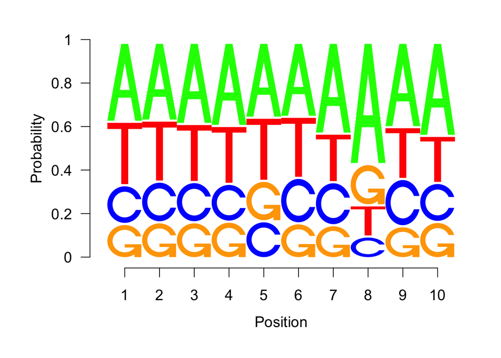

```r
letter_counts <- consensusMatrix(upstrand_seq)
probs <- prop.table(letter_counts[1:4,], 2)

seqLogo(probs, ic.scale=FALSE)
```

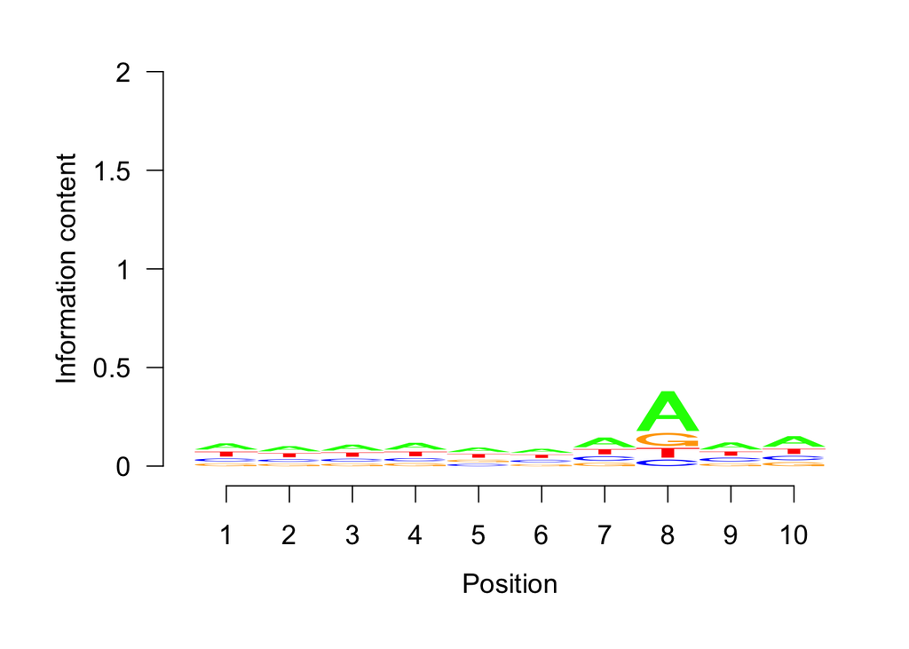

```r
seqLogo(probs)
```

```r
# We may also be interested in k-mer frequencies
colSums( oligonucleotideFrequency(upstrand_seq, 2) )
```

```
##    AA    AC    AG    AT    CA    CC    CG    CT    GA    GC    GG    GT
## 10308  4067  4450  5359  4993  1703  1610  2454  3653  2079  1657  2468
##    TA    TC    TG    TT
##  5687  2919  2205  4616
```